# Chapter 8 Measuring Performance

2022-04-23

# Load R Packages

```r
# install packages from CRAN
p_needed <- c('caret', 'dplyr', 'randomForest',
              'readr', 'car', 'pROC', 'fmsb')

packages <- rownames(installed.packages())
p_to_install <- p_needed[!(p_needed %in% packages)]
if (length(p_to_install) > 0) {
    install.packages(p_to_install)
}

lapply(p_needed, require, character.only = TRUE)
```

In this notebook, we introduce basic model performance measurements for regression and classification problems.

# Regression Model Performance

We first fit a linear regression model on a simulated dataset, and then go through the details about metrics to check for model performance such as MSE, RMSE, and R-Square.

```r
sim.dat <- read.csv("http://bit.ly/2P5gTw4")
fit<- lm(formula = income ~ store_exp + online_exp + store_trans +
    online_trans, data = sim.dat)
summary(fit)
```

```
##
## Call:
## lm(formula = income ~ store_exp + online_exp + store_trans +
##     online_trans, data = sim.dat)
##
## Residuals:
##     Min      1Q  Median      3Q     Max
## -128768  -15804     441   13375  150945
##
## Coefficients:
##                Estimate Std. Error t value Pr(>|t|)
## (Intercept)  85711.6796  3651.5991  23.472  < 2e-16 ***
## store_exp        3.1977     0.4754   6.726 3.28e-11 ***
## online_exp       8.9949     0.8943  10.058  < 2e-16 ***
## store_trans   4631.7507   436.4777  10.612  < 2e-16 ***
## online_trans -1451.1618   178.8355  -8.115 1.80e-15 ***
## ---
## Signif. codes:  0 '***' 0.001 '**' 0.01 '*' 0.05 '.' 0.1 ' ' 1
##
## Residual standard error: 31530 on 811 degrees of freedom
##   (184 observations deleted due to missingness)
## Multiple R-squared:  0.6018, Adjusted R-squared:  0.5998
## F-statistic: 306.4 on 4 and 811 DF,  p-value: < 2.2e-16
```

The fitted results `fit` shows the RMSE is 31530 (at the bottom of the output after `Residual standard error:`).

# Classification Model Performance

In this section, we will fit a random forest model for a classification problem, and then go through typical metrics and plots for model performance.

```r
disease_dat <- read.csv("http://bit.ly/2KXb1Qi")
```

## Train a Random Forest Model

We separate the data into training and testing dataset. We then use the training dataset to train a random forest model, and predict the probability and corresponding classes for the testing dataset using the model trained.

```r
set.seed(100)
# separate the data to be training and testing
trainIndex <- createDataPartition(disease_dat$y, p = 0.8,
                                  list = F, times = 1)

xTrain <- disease_dat[trainIndex, ] %>% dplyr::select(-y)
xTest <- disease_dat[-trainIndex, ] %>% dplyr::select(-y)

# the response variable need to be factor
yTrain <- disease_dat$y[trainIndex] %>% as.factor()
yTest <- disease_dat$y[-trainIndex] %>% as.factor()
```

```r
train_rf <- randomForest(yTrain ~ .,
                         data = xTrain,
                         mtry = trunc(sqrt(ncol(xTrain) - 1)),
                         ntree = 1000,
                         importance = T)
```

```r
yhatprob <- predict(train_rf, xTest, "prob")
set.seed(100)
car::some(yhatprob)
```

```
##         0     1
## 17  0.689 0.311
## 29  0.532 0.468
## 211 0.473 0.527
## 253 0.514 0.486
## 357 0.507 0.493
## 486 0.540 0.460
## 520 0.623 0.377
## 562 0.518 0.482
## 686 0.468 0.532
## 755 0.569 0.431
```

```r
yhat <- predict(train_rf, xTest)
car::some(yhat)
```

```
##   5 141 179 231 245 352 438 696 725 772
##   0   0   0   1   0   0   0   0   1   0
## Levels: 0 1
```

## Confusion Matrix and Kappa Statistic

Confusion matrix is a typical way to check the model performance for classification problems. Kappa statistics measures the agreement between the observed and predicted classes.

```r
yhat = as.factor(yhat) %>% relevel("1")
yTest = as.factor(yTest) %>% relevel("1")
table(yhat, yTest)
```

```
##     yTest
## yhat  1  0
##    1 35 13
##    0 38 74
```

```r
kt<-fmsb::Kappa.test(table(yhat,yTest))
kt$Result
```

```
##
##  Estimate Cohen's kappa statistics and test the null hypothesis that
##  the extent of agreement is same as random (kappa=0)
##
## data:  table(yhat, yTest)
## Z = 4.1451, p-value = 1.698e-05
## 95 percent confidence interval:
##  0.1897309 0.4890256
## sample estimates:
## [1] 0.3393782
```

Kappa can take on a value from -1 to 1. The higher the value, the higher the agreement. A value of 0 means there is no agreement between the observed and predicted classes, while a value of 1 indicates perfect agreement. A negative value indicates that the prediction is in the opposite direction of the observed value. The following table may help you “visualize” the interpretation of kappa:

| Kappa | Agreement |
| --- | --- |
| < 0 | Less than chance agreement |
| 0.01–0.20 | Slight agreement |
| 0.21– 0.40 | Fair agreement |
| 0.41–0.60 | Moderate agreement |
| 0.61–0.80 | Substantial agreement |
| 0.81–0.99 | Almost perfect agreement |

```r
kt$Judgement
```

```
## [1] "Fair agreement"
```

## ROC

ROC (i.e. receiver operating characteristic) curve and AUC (i.e. area under the curve) are two common ways to evaluate classification model performance.

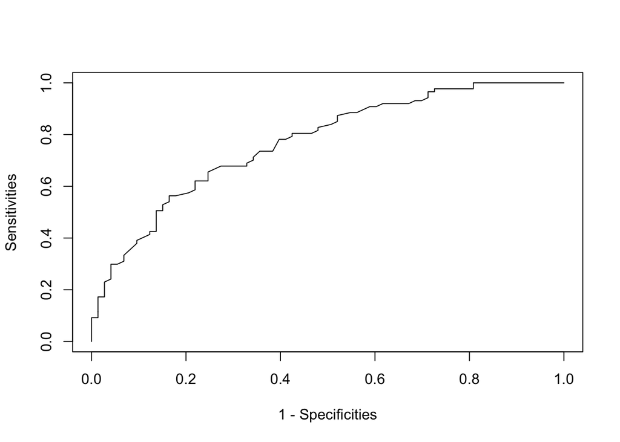

```r
rocCurve <- pROC::roc(response = yTest,
              predictor = yhatprob[,2])

plot(1-rocCurve$specificities,
     rocCurve$sensitivities,
     type = 'l',
     xlab = '1 - Specificities',
     ylab = 'Sensitivities')
```

```r
# get the estimate of AUC
auc(rocCurve)
```

```
## Area under the curve: 0.7694
```

```r
# get a confidence interval based on DeLong et al.
ci.auc(rocCurve)
```

```
## 95% CI: 0.6972-0.8416 (DeLong)
```

## Gain and Lift Charts

Gain and lift chart is another visual tool for evaluating the performance for a classification model. It ranks the samples by their scores and calculate the cumulative positive rate as more samples are evaluated.

```r
table(yTest)
```

```
## yTest
##  1  0
## 73 87
```

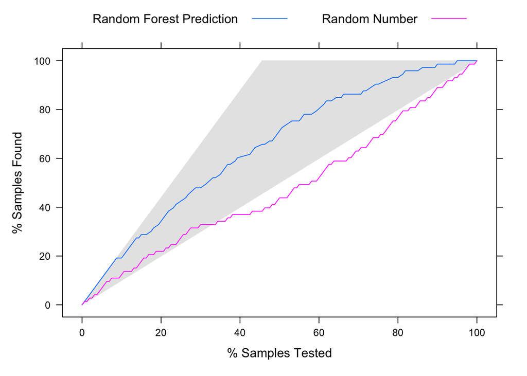

```r
# predicted outbreak probability
modelscore <- yhatprob[ ,2]
# randomly sample from a uniform distribution
randomscore <- runif(length(yTest))
labs <- c(modelscore = "Random Forest Prediction",
        randomscore = "Random Number")
        liftCurve = caret::lift(yTest ~ modelscore + randomscore,
        class = "1",
        labels = labs)

xyplot(liftCurve, auto.key = list(columns = 2, lines = T, points = F))
```